# Part II - Flights Data Presentation

## by Minh Anh Nguyen

## Investigation Overview

This flight data project analysis delay flights and investigate its reasons. The dataset containes flights in the United States with the reasons for delays, in 2006.

## Dataset Overview

The dataset has 7,141,922 flight details with 29 features in year of 2006.

The variables in the dataset contains information about flights' origin, departure, date and time, duration, cancellation status, delay (and cause of delay), etc.

Also, a flight is considered delayed when its arrival delay is longer than 15 minutes.

## Percentage of delayed flights:

- 58% of the total of flights was delayed.
- Flights delayed both on departure and arrival had highest figure, accounted for 37%.
- Arrival Delay and Departure Delay flights contributed 12% and 9% respectively.

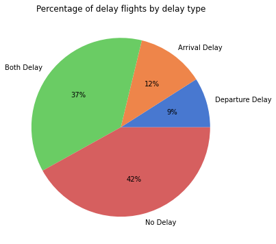

## Delay time distribution:

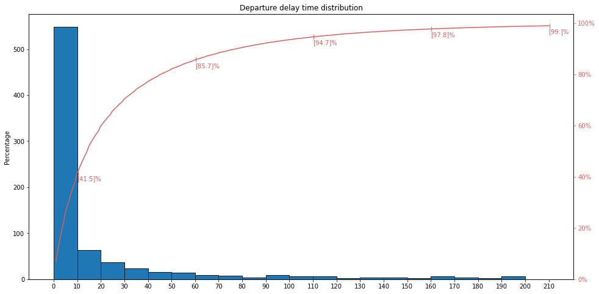

## Worst time to book flights

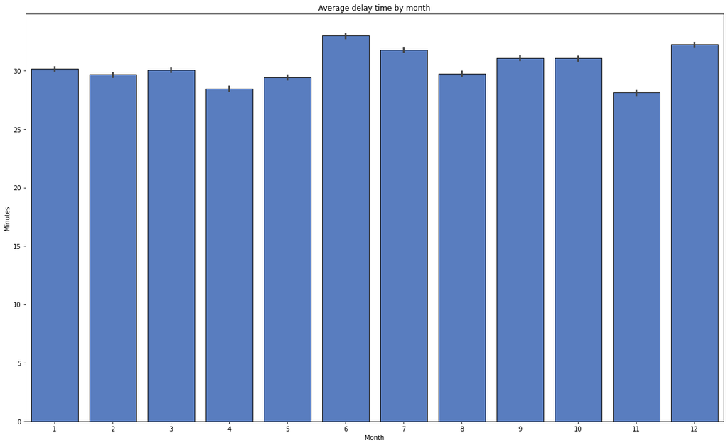

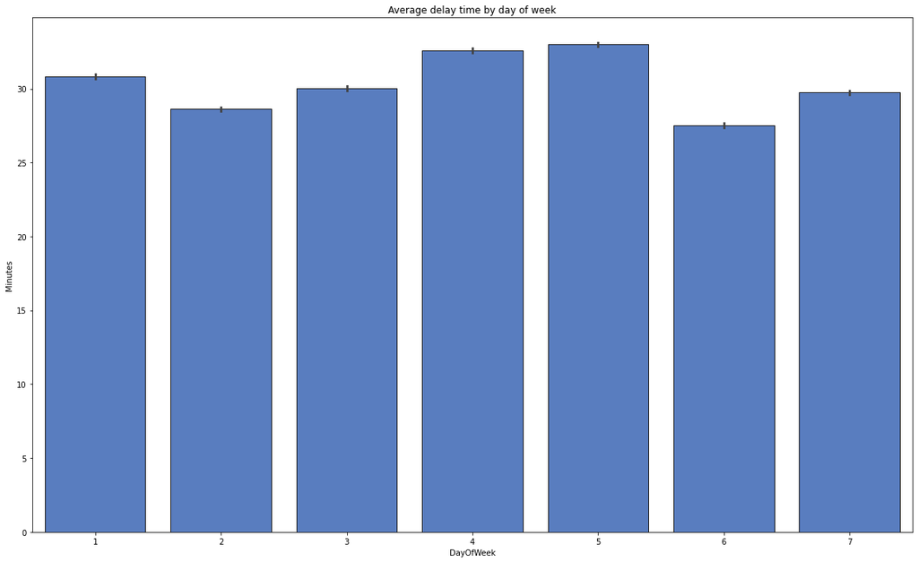

## Worst airline to book flights

- The Atlantic Southeast Airlines has the longest average delay time, which was 16,4 minutes. Mesa and ATA Airlines placed second and third with 14 and 12 minutes respecively.
- The Southwest Airlines has the highest number and percentage of delayed flights, which had nearly 518 thousands delayed flights and accounted for 47% total flights of this airlines. Though Atlantic Southeast Airlines had less flights than many other airlines, it delayed 46% (second-highest) of its flights.

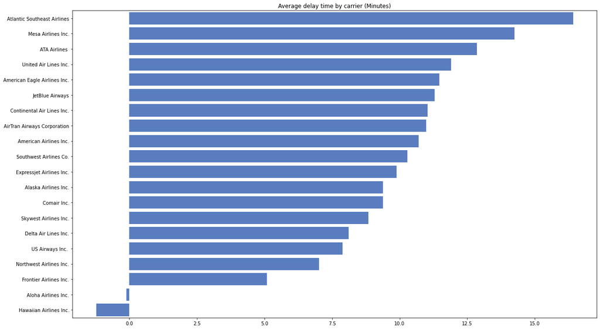

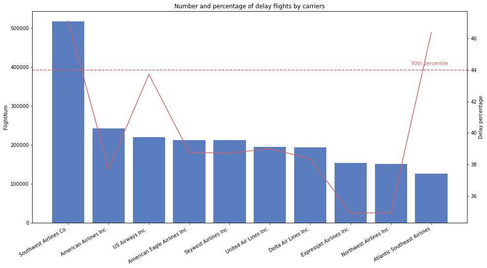

## Worst place to book flights

- Original place to take off: Chicago and Alanta has the highest number and percentage of delayed flights, which had more than 200 thousands delayed flights and accounted for 48 and 50% total flights took off respectively. Though Las Vegas had less delayed flights than many other airlines, it delayed 49% (second-highest) of its flights.
- Destination place to land off: Chicago, Alanta and Dallas-Fort Worth also top 3 highest number of delayed flights.

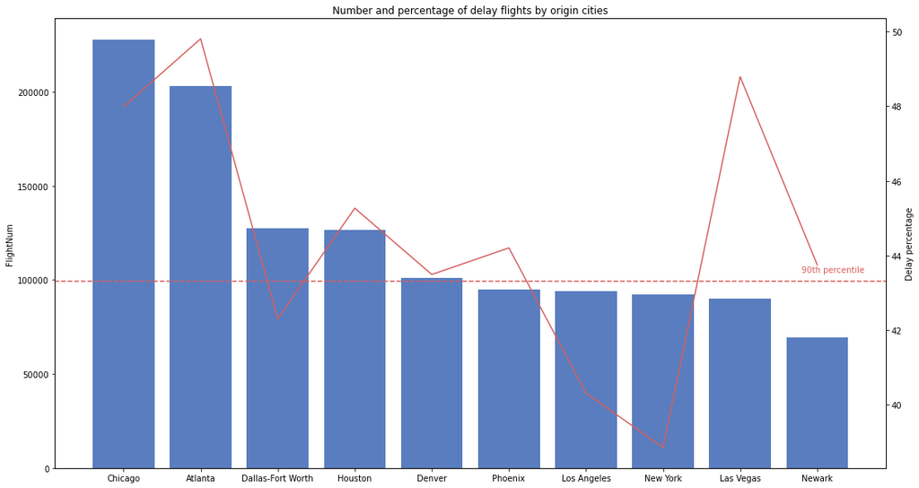

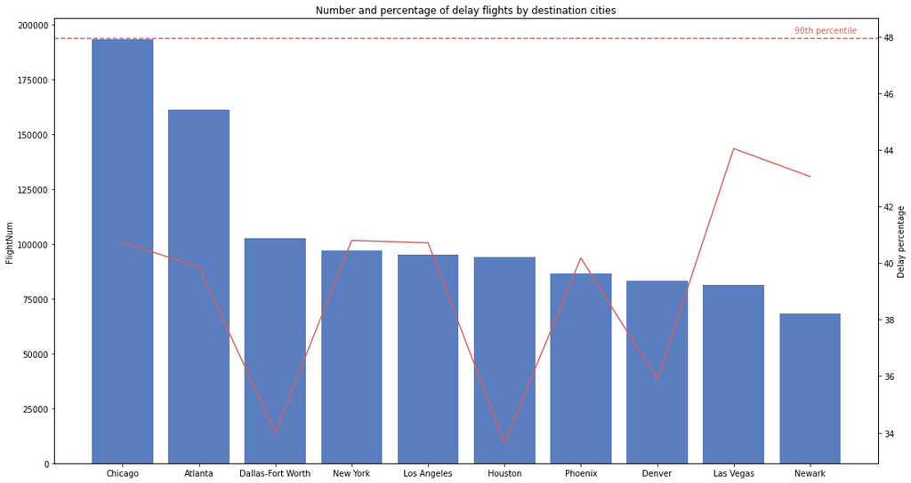

## Main reason for delay flights

- Both Arrival and Departure delay also have ~0.5 correlation with Carrier and Late Aircraft delay meaning that in case of Carrier and Late Aircraft delay, the flight has higher chance of departing/arriving late.
- Late Aircraft were main reasons of delayed flights, followed by NAS and Carrier.

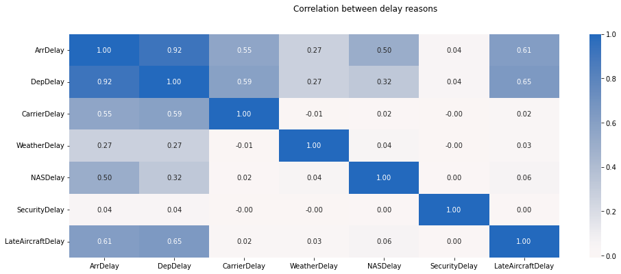

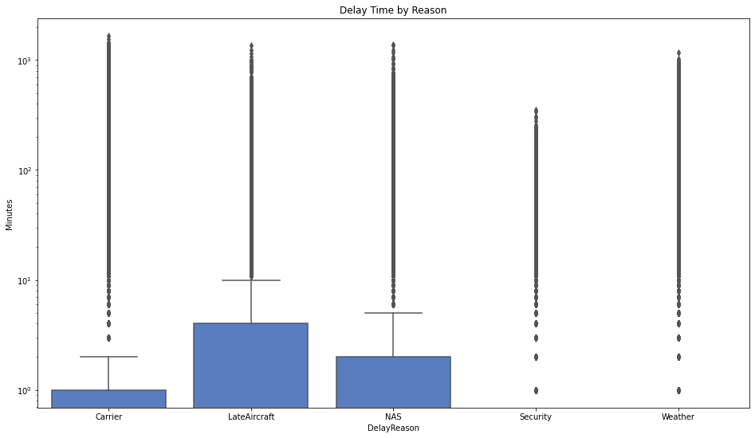